# Assignment-2

Tumay Kir

8/18/2020

# Electricity Price Analysis & Report (July 2020)

## Data

```r
data<-read.csv("C:/Users/tumay/Desktop/ptf-smf.csv")
head(data)
```

```
##             Date    MCP SMP
## 1 01.07.20 00:00 323.85 211
## 2 01.07.20 01:00 326.95 201
## 3 01.07.20 02:00 324.31 211
## 4 01.07.20 03:00 322.11 211
## 5 01.07.20 04:00 320.00 201
## 6 01.07.20 05:00 286.21 181
```

```r
data %>% glimpse()
```

```
## Rows: 744
## Columns: 3
## $ Date <chr> "01.07.20 00:00", "01.07.20 01:00", "01.07.20 02:00", "01.07.2...
## $ MCP  <dbl> 323.85, 326.95, 324.31, 322.11, 320.00, 286.21, 210.13, 318.20...
## $ SMP  <dbl> 211.00, 201.00, 211.00, 211.00, 201.00, 181.00, 113.75, 201.00...
```

In order to analyze the data, some arrangements should be made. First of all, the date information in my csv file includes dots, so it should change into the default date format, which is %Y-%m-%d. Also, date and time information should be split so that the electricity prices in July 2020 can be examined according to the hours and days, respectively.

```r
data<-separate(data,col=Date,into=c("Date","Hour"),sep=" ")
data$Date<-gsub('\\.', '/',data$Date)
data$date<-data$Date
data<-separate(data,col=date,into=c("Day","Month","Year"),sep="/")
a<-as.factor(data$Date)
abis<-strptime(a,format="%d/%m/%y") #defining what is the original format of my date
data$Date<-as.Date(abis,format="%Y-%m-%d")
class(data$Date)
```

```
## [1] "Date"
```

```r
data$Day = strftime(data$Date,'%A')
data$Month = strftime(data$Date,'%B')

data<-data%>%
  mutate(diff=MCP-SMP)

head(data)
```

```
##         Date  Hour    MCP SMP       Day Month Year   diff
## 1 2020-07-01 00:00 323.85 211 Wednesday  July   20 112.85
## 2 2020-07-01 01:00 326.95 201 Wednesday  July   20 125.95
## 3 2020-07-01 02:00 324.31 211 Wednesday  July   20 113.31
## 4 2020-07-01 03:00 322.11 211 Wednesday  July   20 111.11
## 5 2020-07-01 04:00 320.00 201 Wednesday  July   20 119.00
## 6 2020-07-01 05:00 286.21 181 Wednesday  July   20 105.21
```

The difference between MCP and SMP is an indicator to see the mispredictions and underestimated time periods in the data.

```r
data %>% glimpse()
```

```
## Rows: 744
## Columns: 8
## $ Date  <date> 2020-07-01, 2020-07-01, 2020-07-01, 2020-07-01, 2020-07-01, ...
## $ Hour  <chr> "00:00", "01:00", "02:00", "03:00", "04:00", "05:00", "06:00"...
## $ MCP   <dbl> 323.85, 326.95, 324.31, 322.11, 320.00, 286.21, 210.13, 318.2...
## $ SMP   <dbl> 211.00, 201.00, 211.00, 211.00, 201.00, 181.00, 113.75, 201.0...
## $ Day   <chr> "Wednesday", "Wednesday", "Wednesday", "Wednesday", "Wednesda...
## $ Month <chr> "July", "July", "July", "July", "July", "July", "July", "July...
## $ Year  <chr> "20", "20", "20", "20", "20", "20", "20", "20", "20", "20", "...
## $ diff  <dbl> 112.85, 125.95, 113.31, 111.11, 119.00, 105.21, 96.38, 117.20...
```

`by_hour` data contains the mean of SMP and MCP with respect to the hours. It also shows their difference hour by hour. This plot represents the average SMP values on the y-axis and the hours of the day on the x-axis.

```r
by_hour<- data %>% group_by(Hour)%>%
  summarize(mean_hour_SMP=mean(SMP),mean_hour_MCP=mean(MCP),diff=mean_hour_SMP-mean_hour_MCP)
```

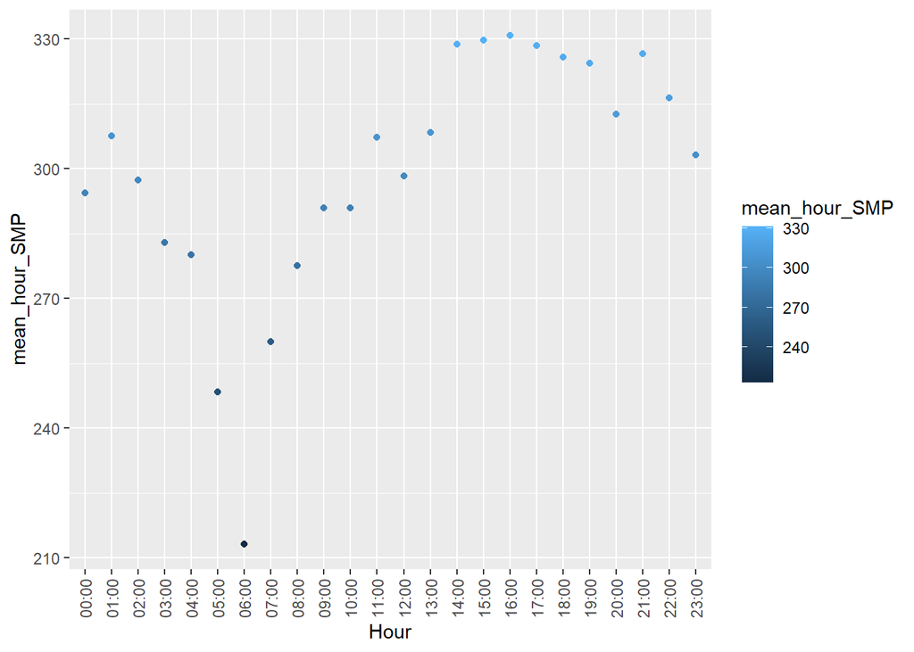

```r
ggplot(by_hour, aes(x=Hour, y=mean_hour_SMP,color=mean_hour_SMP))+
  geom_point()+
    theme(axis.text.x = element_text(angle = 90, vjust = .5))
```

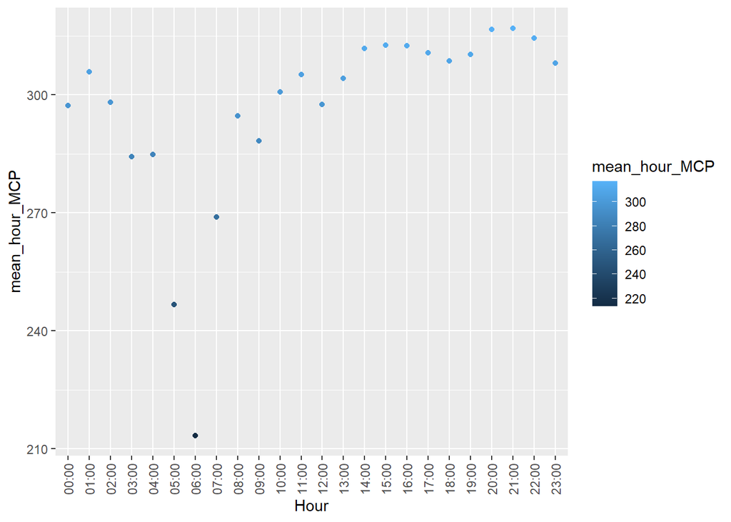

```r
ggplot(by_hour, aes(x=Hour, y=mean_hour_MCP,color=mean_hour_MCP))+
  geom_point()+
    theme(axis.text.x = element_text(angle = 90, vjust = .5))
```

With this boxplot, it can be shown that how the System Marginal Prices changed during the days of July. For example, the plot takes all the SMP values for fridays and creates a boxplot for that day. Therefore, it can be seen that the weighted prices according to the days with all the outliers.

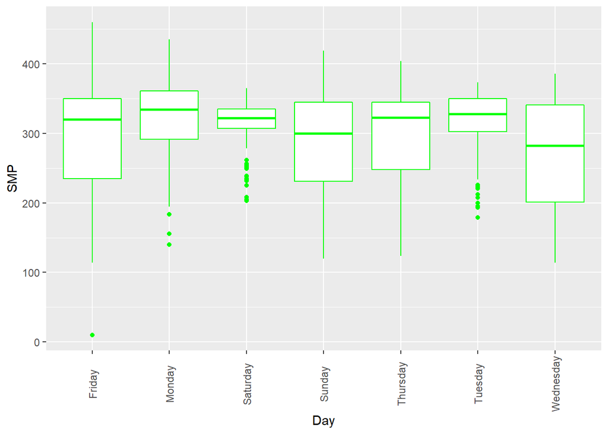

```r
ggplot(data,aes(x=Day,y=SMP))+
  geom_boxplot(color= "green")+
    theme(axis.text.x = element_text(angle = 90, vjust = .5))
```

`by_day` data contains the mean of SMP and MCP with respect to the days. It also shows their difference day by day. This plot represents the average SMP values on the y-axis and the days of a week on the x-axis.

```r
by_day<-data%>%
  group_by(Day)%>%
    summarize(mean_day_SMP=mean(SMP),mean_day_MCP=mean(MCP),diff=mean_day_SMP-mean_day_MCP)
```

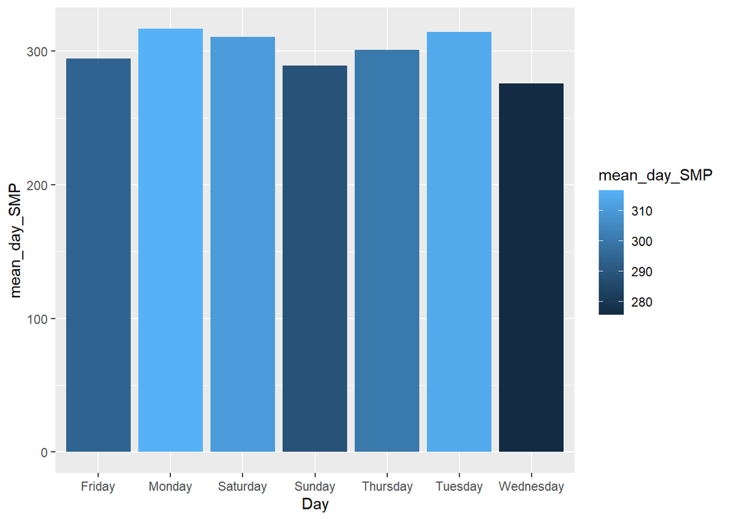

```r
ggplot(by_day,aes(x=Day,y=mean_day_SMP))+
  geom_col(aes(fill=mean_day_SMP))
```

This plot represents the average MCP values on the y-axis and the days of a week on the x-axis.

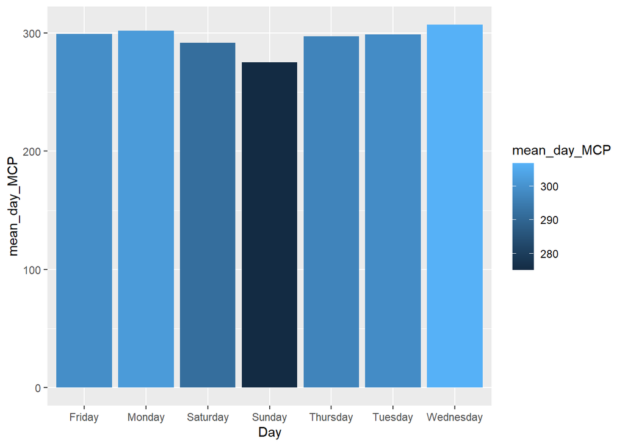

```r
ggplot(by_day,aes(x=Day,y=mean_day_MCP))+
  geom_col(aes(fill=mean_day_MCP))
```

These bars provide a look from a broader perspective by showing both the SMP and MCP data together with respect to days.

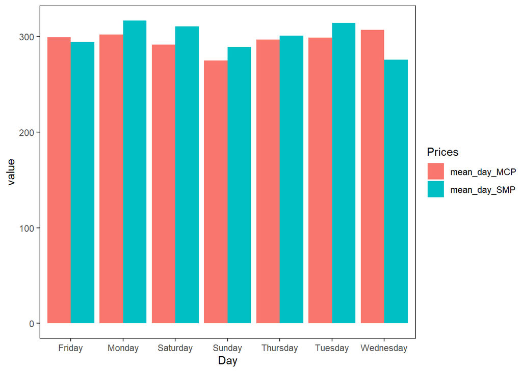

```r
by_day_pivot<-by_day%>%
  pivot_longer(cols=c(mean_day_SMP, mean_day_MCP), names_to="Prices")

ggplot(by_day_pivot,aes(x=Day,y=value,fill=Prices))+
    geom_bar(stat="identity", position="dodge")+
      theme_test()
```

These bars provide a look from a broader perspective by showing both the SMP and MCP data together with respect to hours.

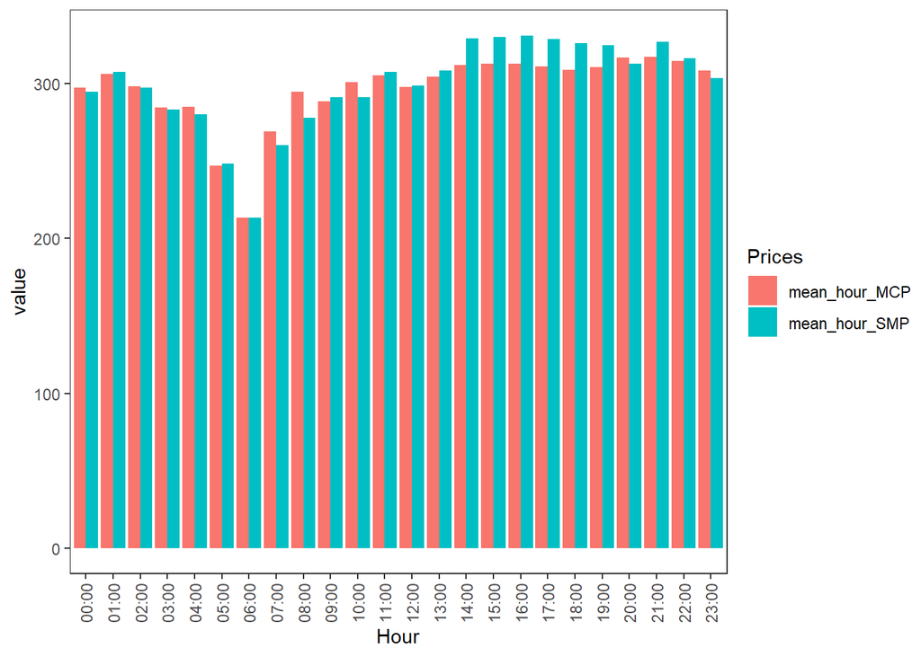

```r
by_hour_pivot<-by_hour%>%
  pivot_longer(cols=c(mean_hour_SMP, mean_hour_MCP), names_to="Prices")

ggplot(by_hour_pivot,aes(x=Hour,y=value,fill=Prices))+
     geom_bar(stat="identity", position="dodge")+
      theme_test()+
        theme(axis.text.x = element_text(angle = 90, vjust = .5))
```

By looking the last two plots, it can be said that the highest average prices (SMP) are generally on Monday at 4pm. So, electricity consumption is higher during that day and hour.

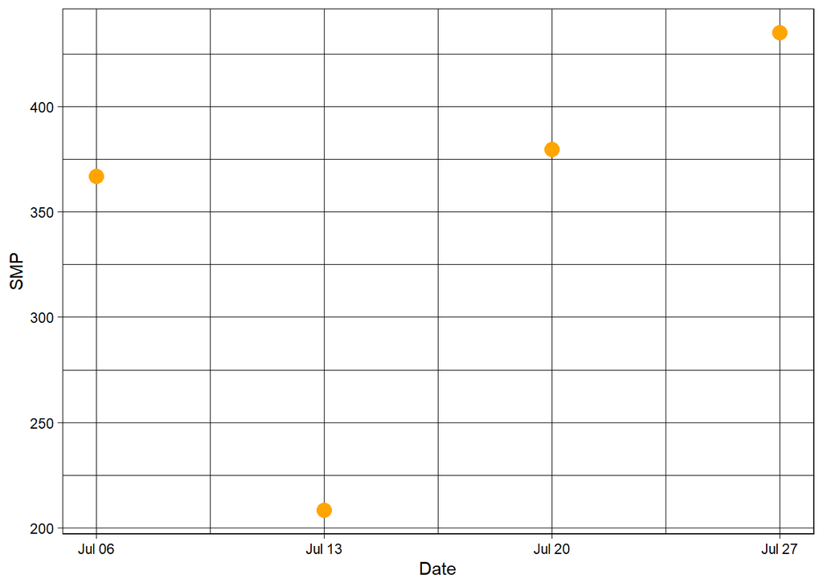

```r
data_monday_16<- data%>%
  filter(Day=="Monday",Hour=="16:00")

ggplot(data_monday_16,aes(x=Date,y=SMP))+
  geom_point(size= 4,color="orange")+
    theme_linedraw()
```

By looking the last two plots, it can be said that the lowest average prices (SMP) are generally on Wednesday at 6am. So, electricity consumption is lower during that day and hour.

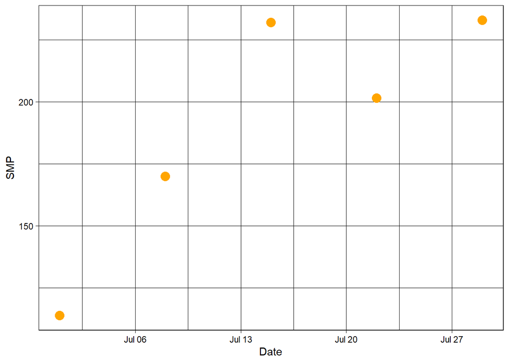

```r
data_wed_06<- data%>%
  filter(Day=="Wednesday",Hour=="06:00")

ggplot(data_wed_06,aes(x=Date,y=SMP))+
  geom_point(size= 4,color="orange")+
    theme_linedraw()
```

## The Relation between SMP and MCP

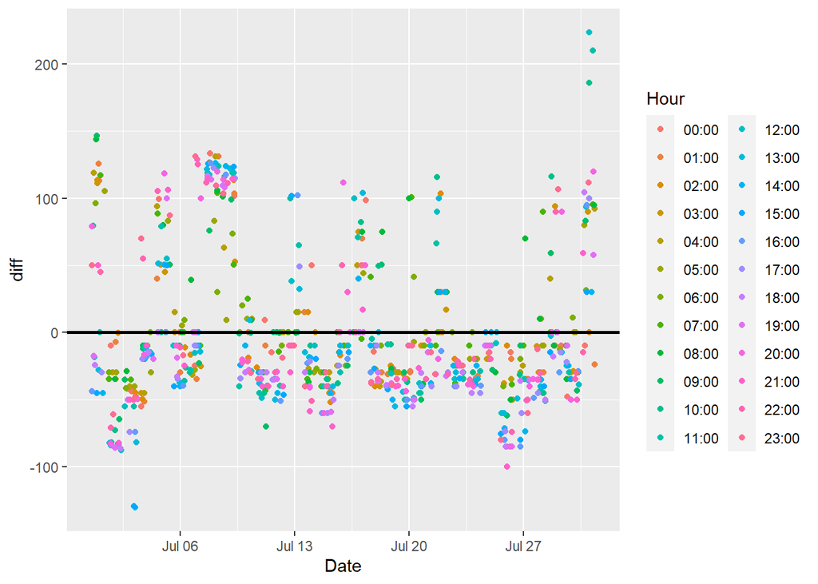

```r
ggplot(data,aes(Date,diff,color=Hour))+
  geom_point(position="jitter")+
    geom_abline(slope=0, intercept=0, color="black",size=1)
```

## Original SMP vs. MCP Data (wrt days)

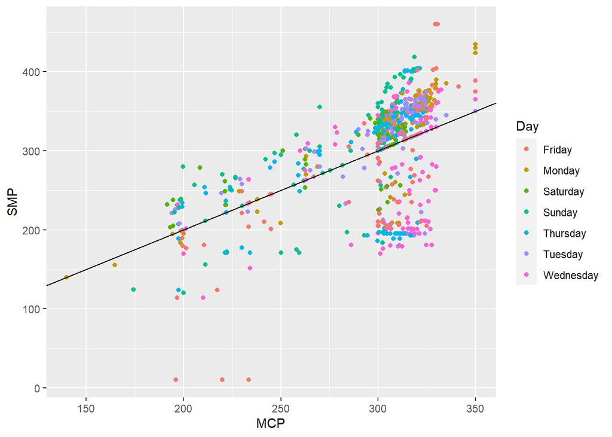

```r
ggplot(data,aes(MCP,SMP,color=Day))+
  geom_point()+
    geom_abline(color="black")
```

Since this table has the `diff` column with respect to the hours of a day, the energy deficit/surplus interpretations can be made easily.

```r
by_hour
```

```
## # A tibble: 24 x 4
##    Hour  mean_hour_SMP mean_hour_MCP    diff
##    <chr>         <dbl>         <dbl>   <dbl>
##  1 00:00          294.          297.  -3.03
##  2 01:00          308.          306.   1.70
##  3 02:00          297.          298.  -0.767
##  4 03:00          283.          284.  -1.35
##  5 04:00          280.          285.  -4.81
##  6 05:00          248.          247.   1.64
##  7 06:00          213.          213.  -0.219
##  8 07:00          260.          269.  -8.97
##  9 08:00          278.          295. -17.0
## 10 09:00          291.          288.   2.64
## # ... with 14 more rows
```

Since this table has the `diff` column with respect to the days of July, the energy deficit/surplus interpretations can be made easily.

```r
by_day
```

```
## # A tibble: 7 x 4
##   Day       mean_day_SMP mean_day_MCP   diff
##   <chr>            <dbl>        <dbl>  <dbl>
## 1 Friday            294.         299.  -4.81
## 2 Monday            317.         302.  14.7
## 3 Saturday          311.         292.  19.0
## 4 Sunday            289.         275.  14.0
## 5 Thursday          301.         297.   3.79
## 6 Tuesday           314.         299.  15.6
## 7 Wednesday         276.         307. -31.1
```

Finally, both average MCP and average SMP values can be seen in the same plot during July. The intervals which the difference between SMP and MCP are either negative or positive are clearly shown in this figure.

```r
by_date<-data %>%
  group_by(Date) %>%
    summarise(mean_MCP = mean(MCP), mean_SMP = mean(SMP)) %>%
      pivot_longer(cols=c(mean_SMP, mean_MCP), names_to="Prices")
```

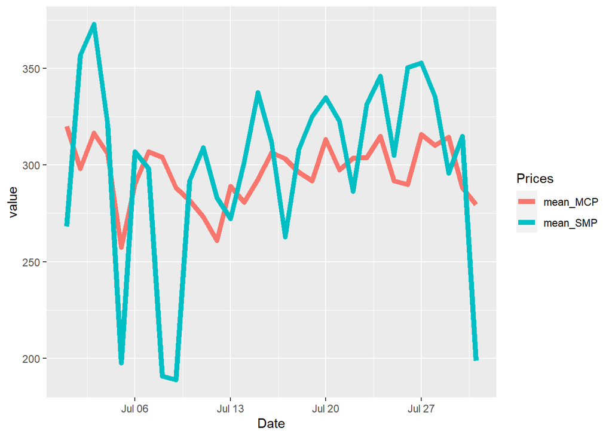

```r
ggplot(by_date,aes(x=Date,y=value,color=Prices))+
     geom_line(size=2)
```